# PA1_template

Daniel Cialdella - dcialdella@gmail.com

August 18, 2016

## Reproducible Research Course 5 - Week 2

### Commit containing full submission.

1. Code for reading in the dataset and/or processing the data
2. Histogram of the total number of steps taken each day
3. Mean and median number of steps taken each day
4. Time series plot of the average number of steps taken
5. The 5-minute interval that, on average, contains the maximum number of steps
6. Code to describe and show a strategy for imputing missing data
7. Histogram of the total number of steps taken each day after missing values are imputed
8. Panel plot comparing the average number of steps taken per 5-minute interval across weekdays and weekends
9. All of the R code needed to reproduce the results (numbers, plots, etc.) in the report

### Introduction

It is now possible to collect a large amount of data about personal movement using activity monitoring devices such as a Fitbit, Nike Fuelband, or Jawbone Up. These type of devices are part of the “quantified self” movement – a group of enthusiasts who take measurements about themselves regularly to improve their health, to find patterns in their behavior, or because they are tech geeks. But these data remain under-utilized both because the raw data are hard to obtain and there is a lack of statistical methods and software for processing and interpreting the data.

This assignment makes use of data from a personal activity monitoring device. This device collects data at 5 minute intervals through out the day. The data consists of two months of data from an anonymous individual collected during the months of October and November, 2012 and include the number of steps taken in 5 minute intervals each day.

### About the data (Input File)

The data for this assignment can be downloaded from the course web site: Dataset: Activity monitoring data [52K] - 17568 records / 3 columns

The variables included in this dataset are: steps: Number of steps taking in a 5-minute interval (missing values are coded as NA) date: The date on which the measurement was taken in YYYY-MM-DD format interval: Identifier for the 5-minute interval in which measurement was taken

The dataset is stored in a comma-separated-value (CSV) file and there are a total of 17,568 observations in this dataset.

### 1. Loading and preprocessing the data

#### 1.1 Load the data (i.e. read.csv())

```r
activity  <- read.csv("activity.csv")
```

#### 1.2 Process/transform the data (if necessary) into a format suitable for your analysis

Pre-calculate date with valid data, see kind of data for activity2 (without NA)

```r
dates <- unique( strptime(activity$date, "%Y-%m-%d") )

activity2 <- na.omit(activity)
dates2    <- unique( strptime(activity2$date, "%Y-%m-%d") )

min(dates2)
```

```
## [1] "2012-10-02 CEST"
```

```r
max(dates2)
```

```
## [1] "2012-11-29 CET"
```

```r
dim(activity2)
```

```
## [1] 15264     3
```

```r
head(activity2,10)
```

```
##     steps       date interval
## 289     0 2012-10-02        0
## 290     0 2012-10-02        5
## 291     0 2012-10-02       10
## 292     0 2012-10-02       15
## 293     0 2012-10-02       20
## 294     0 2012-10-02       25
## 295     0 2012-10-02       30
## 296     0 2012-10-02       35
## 297     0 2012-10-02       40
## 298     0 2012-10-02       45
```

### 2. What is mean total number of steps taken per day?

#### 2.1 Calculate the total number of steps taken per day

Calculating activities by day.

```r
activitybydaySum <- aggregate( list(activity2$steps),  list(activity2$date), sum )
names(activitybydaySum) = c("date","steps")

activitybydayAver  <- aggregate( list(activity2$steps),  list(activity2$date), mean )
names(activitybydayAver) = c("date","steps")

head(activitybydaySum, 20)
```

```
##          date steps
## 1  2012-10-02   126
## 2  2012-10-03 11352
## 3  2012-10-04 12116
## 4  2012-10-05 13294
## 5  2012-10-06 15420
## 6  2012-10-07 11015
## 7  2012-10-09 12811
## 8  2012-10-10  9900
## 9  2012-10-11 10304
## 10 2012-10-12 17382
## 11 2012-10-13 12426
## 12 2012-10-14 15098
## 13 2012-10-15 10139
## 14 2012-10-16 15084
## 15 2012-10-17 13452
## 16 2012-10-18 10056
## 17 2012-10-19 11829
## 18 2012-10-20 10395
## 19 2012-10-21  8821
## 20 2012-10-22 13460
```

```r
summary(activitybydaySum$steps)
```

```
##    Min. 1st Qu.  Median    Mean 3rd Qu.    Max.
##      41    8841   10760   10770   13290   21190
```

Graphic showing Activities by day

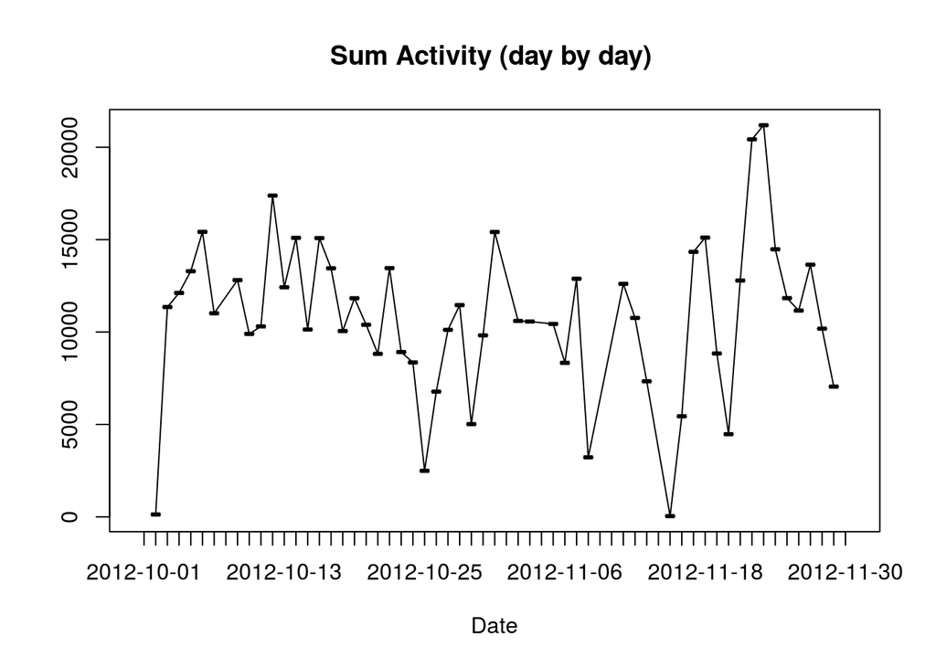

```r
plot( activitybydaySum$date, activitybydaySum$steps , main="Sum Activity (day by day) ", lwd=1, xlab="Date")
lines( activitybydaySum$date, activitybydaySum$steps , type="l")
```

#### 2.2 If you do not understand the difference between a histogram and a barplot, research the difference between them. Make a histogram of the total number of steps taken each day

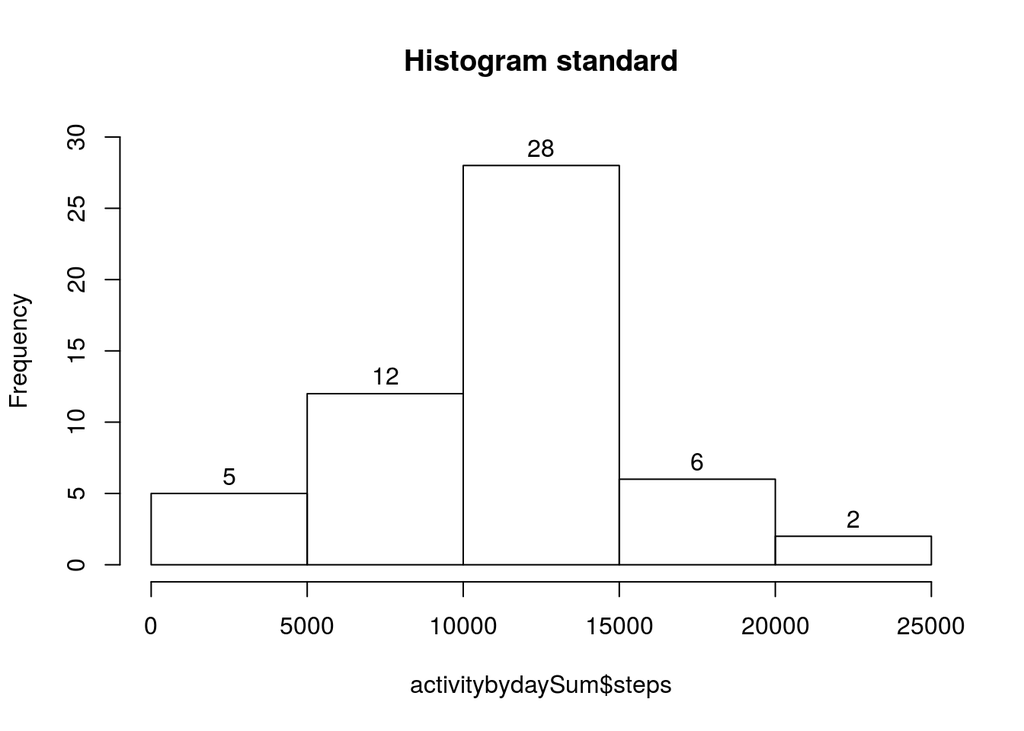

```r
hist(activitybydaySum$steps, main="Histogram standard", labels=TRUE, ylim=c(0,30))
```

Slides by 10

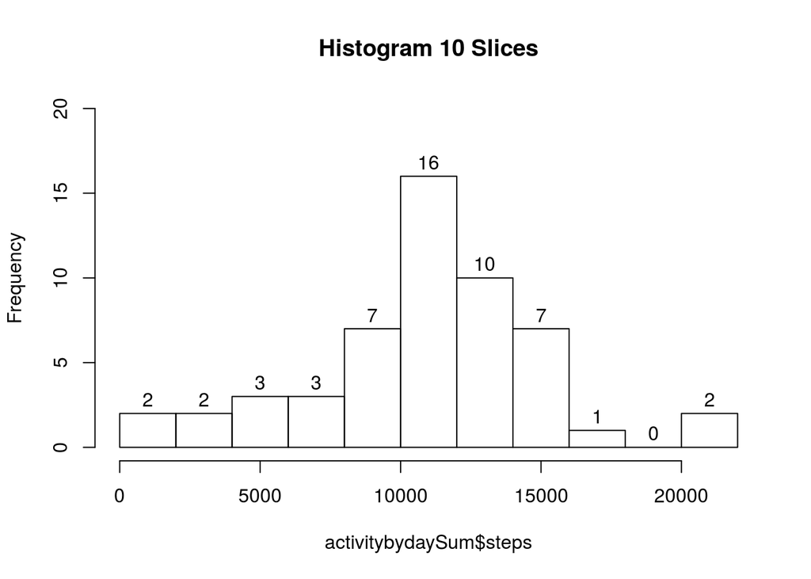

```r
hist(activitybydaySum$steps, breaks=10, main="Histogram 10 Slices", labels=TRUE, ylim=c(0,20))
```

Slides by 20

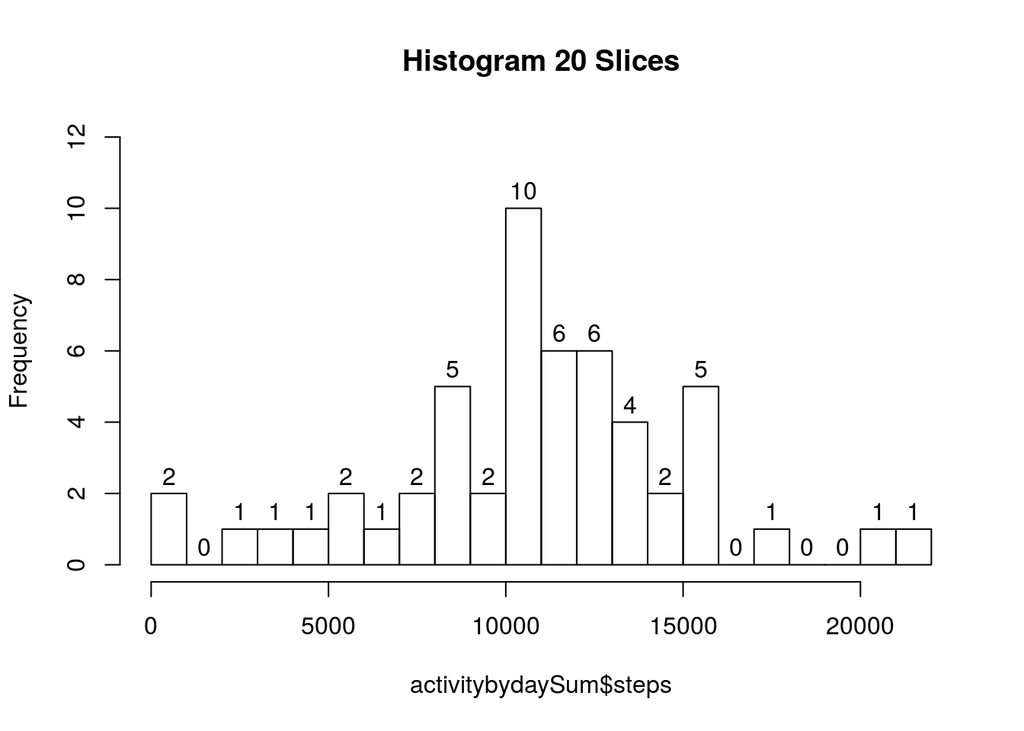

```r
hist(activitybydaySum$steps, breaks=20, main="Histogram 20 Slices", labels=TRUE, ylim=c(0,12))
```